# Dealing with complicated data in time series models

12 Mar 2019

## Modeling zero-inflated data

Zero-inflated = data with excess of zero counts

The degree of zero-inflation may be extreme

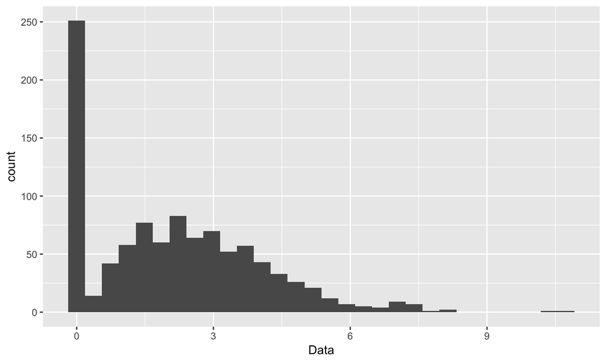

## Modeling zero-inflated data

Zero-inflated = data with excess of zero counts

Or more subtle

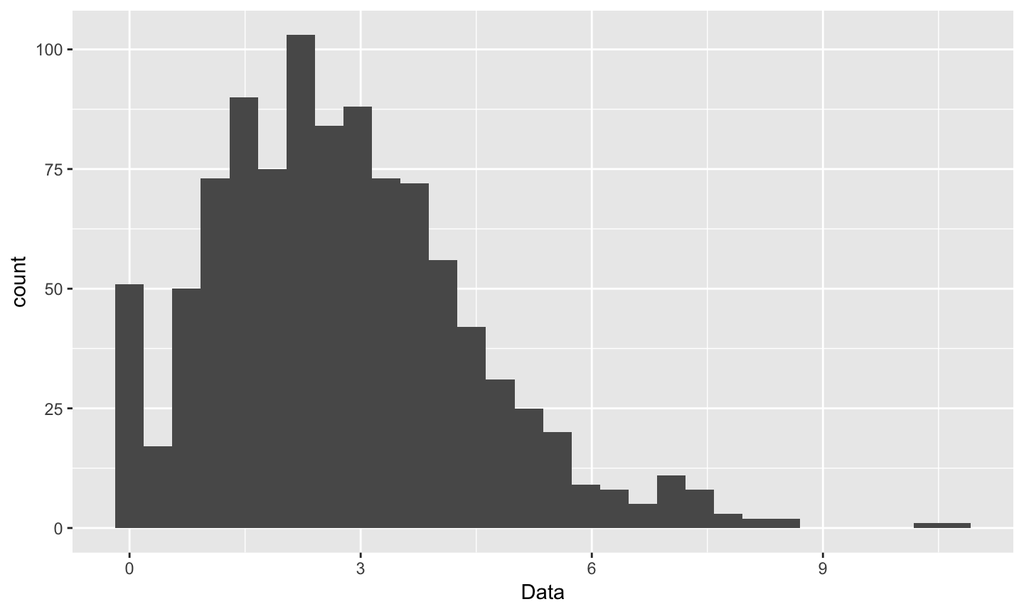

## Lots of options for dealing with zeros

1. Remove them from the dataset and ignore them
2. Transform your data
3. Work with complicated statistical models

## 1. Dropping zeros

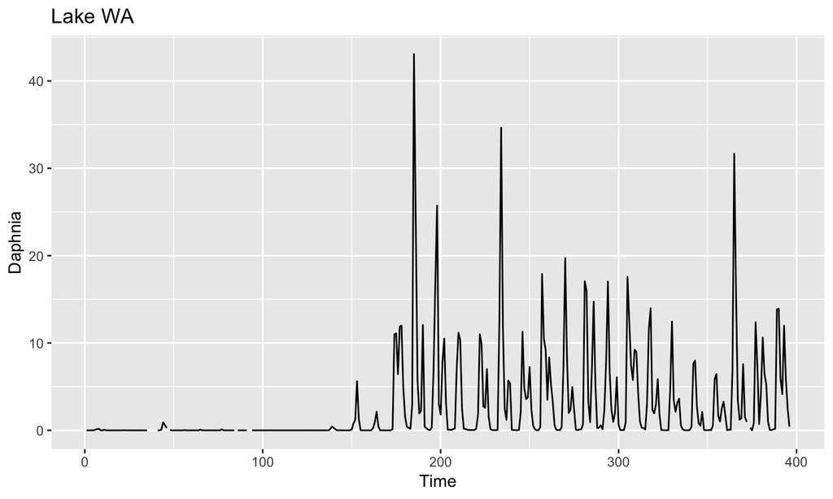

## 1. Dropping zeros

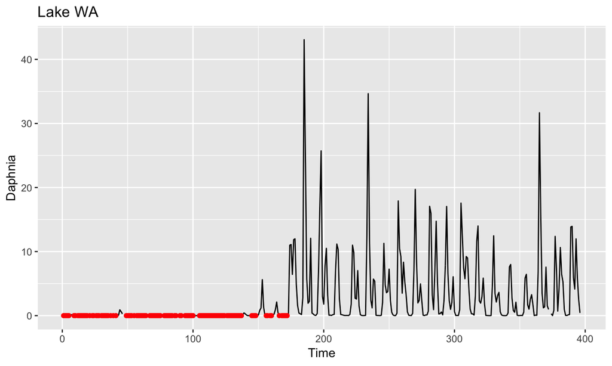

## 1. Dropping zeros

Can work in a limited number of cases BUT

Becomes problematic for

- models that depend on autoregressive structure
- models that don’t allow for missing data / NAs
- datasets where the zeros aren’t random (Daphnia example)
- zeros are caused by response (density dependence, etc)

## 2. Transforming data

With zero-inflated data, it’s common to add a small number and transform the results – ln(), sqrt(), etc.

- Problem: what constant should be added before we apply the transformation?

## Example: Lake WA Conochilus

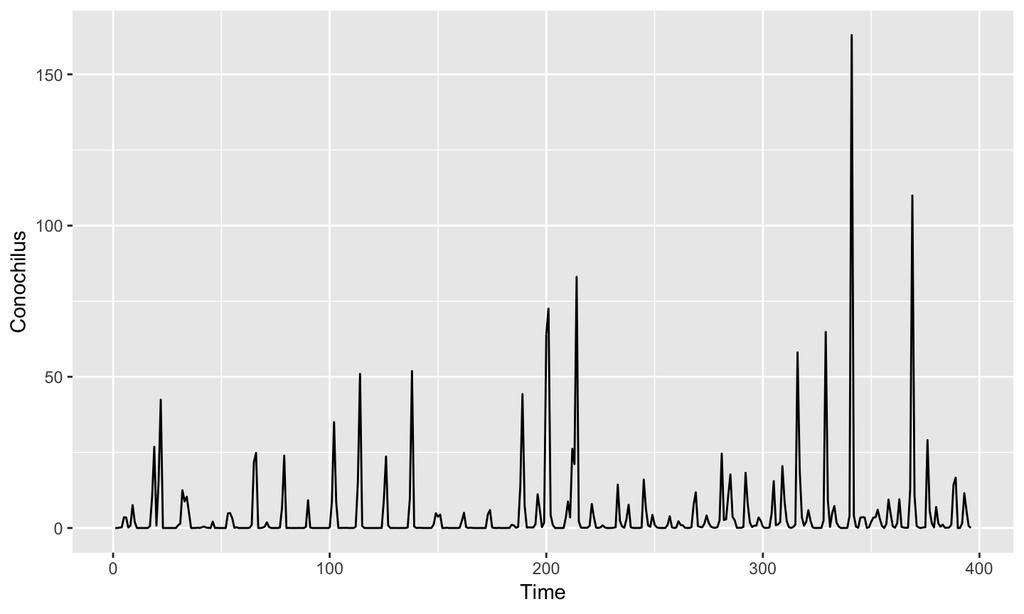

## Example: Lake WA Conochilus

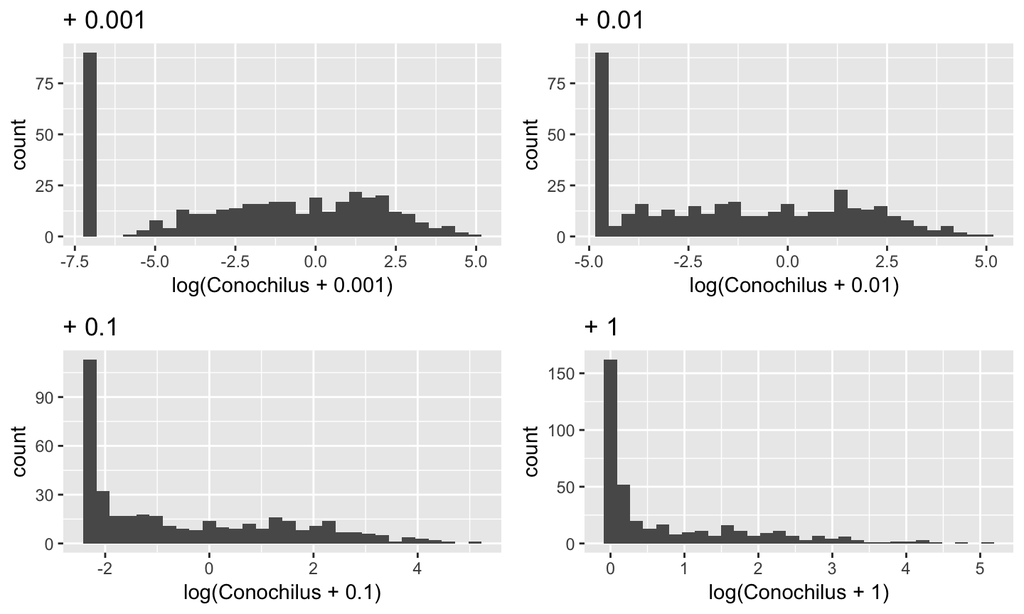

## Example: Lake WA Conochilus

Lots of problems with this approach generally

- choice of constant is subjective
- leads to biases in parameters being estimated

Example: let’s fit auto.arima() to this time series using different constants

## Example: Lake WA Conochilus

log(Conochilus + 0.001) = ARIMA(3,1,1) + no drift

log(Conochilus + 0.01) = ARIMA(3,1,2) + no drift

log(Conochilus + 0.1) = ARIMA(2,1,1) + no drift

log(Conochilus + 1) = ARIMA(5,1,0) + drift

## References for adding constants (or not)

Ekwaru et al. 2017 [link](https://amstat.tandfonline.com/doi/abs/10.1080/19466315.2017.1369900?journalCode=usbr20#.XIe-RBNKiM4)

O’hara and Kotze 2010 [link](https://besjournals.onlinelibrary.wiley.com/doi/full/10.1111/j.2041-210X.2010.00021.x)

## 3. Using more complicated statistical models

1. Tweedie distribution
2. Delta or hurdle- models

## Tweedie distribution

- Tweedie is very flexible
- Skewed continuous distribution with point mass at zero
  - unlike Gamma, which is undefined at zero

## Implementation in R

Lots of existing family support

- Specify link function (*q*) - related predicted values to covariates

\(μ_i^q = x_i^Tb\)

- Specify power function (*p*) - relates variance to mean

\(var(y_i) = phi * μ_i^p\)

- When 1 < *p* < 2, behavior is compound Poisson / Tweedie

## Let’s apply GLMs with Tweedie to Lake WA data

```r
library(statmod)
g = glm(Conochilus ~ 1, family=
    tweedie(var.power=1.3,link.power=0),
  data=as.data.frame(lakeWAplanktonRaw))
```

## What’s the right variance power to choose?

Package ‘tweedie’ does ML estimation of the *p* parameter.

```r
library(tweedie)
tp = tweedie.profile(Conochilus ~ 1,
  p.vec = seq(1,2,by=0.1),
  data=as.data.frame(lakeWAplanktonRaw))
```

## What’s the right variance power to choose?

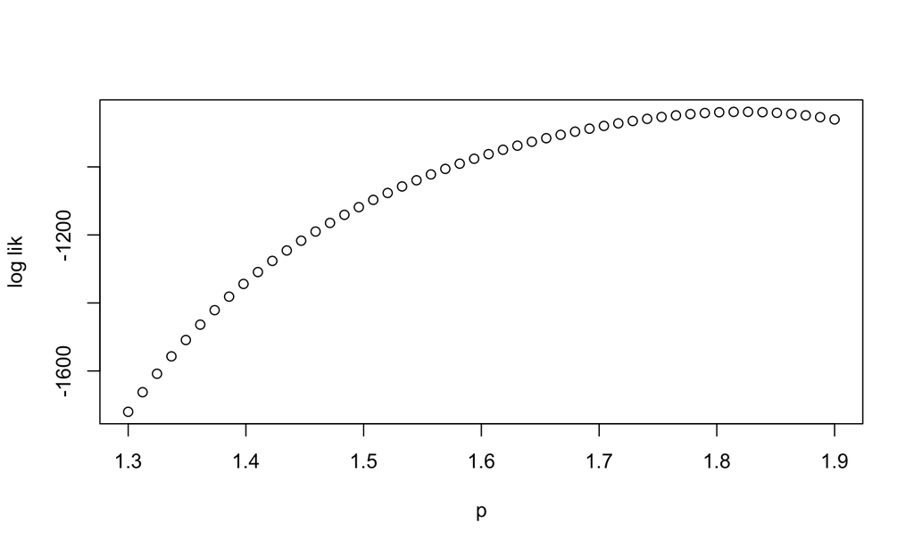

```r
plot(tp, xlab="p", ylab="log lik")
```

## Other implementations in R

Also supported in ‘mgcv’. *p* parameter may be fixed

```r
gam(Conochilus~s(year), family=Tweedie(1.25,power(.1)),
  data=as.data.frame(lakeWAplanktonRaw))
```

or estimated

```r
gam(Conochilus~s(year), family=tw(),
  data=as.data.frame(lakeWAplanktonRaw))
```

## Delta (aka hurdle models)

Tweedie models every data point as being generated from the same process

Alternative: use delta- or hurdle- models

- These model the zeros with one sub-model, and the positive values with a second sub-model
- Very widely used in fisheries (index standardization etc)

## Sub-models

Binomial data (logit link) \(logit(p_i) = log(p_i/(1-p_i)) = BX_i\)

Positive model (log link generally) \(log(u_i) = CZ_i\)

- Poisson, Gamma, NegBinomial, etc
- \(Z_i\) and \(X_i\) may be identical
- Where are the error terms? (GLMMs)

## Time series

Adding these error terms allow us to turn conventional GLM into time series models with autoregressive behavior, e.g. \[Y_t \sim Bernoulli(p_t)\] \[logit(p_t) = BX_t \] \[X_{t} = BX_{t-1} + \epsilon_{t-1}\] \[\epsilon_t \sim Normal(0, \sigma)\]

- Any DLM or SS model can be extended to include non-normal errors

## Hurdle models

Delta-GLM: We’ll start fitting 2 models to the Conochilus data

```r
lakeWAplanktonRaw = as.data.frame(lakeWAplanktonRaw)
lakeWAplanktonRaw$present =
  ifelse(lakeWAplanktonRaw$Conochilus > 0, 1, 0)

model_01 = glm(present ~ Year + as.factor(Month),
  data=lakeWAplanktonRaw, family = binomial)
model_pos = glm(Conochilus ~ Year + as.factor(Month),
  data=lakeWAplanktonRaw[which(lakeWAplanktonRaw$Conochilus>0),],
  family = Gamma(link="log"))
```

## Hurdle models

Now we can combine predictions from these models for estimates of Conochilus density

```r
lakeWAplanktonRaw$glm_pred = predict(model_01,
  newdata=lakeWAplanktonRaw, type="response") *
  predict(model_pos,
  newdata=lakeWAplanktonRaw, type="response")
```

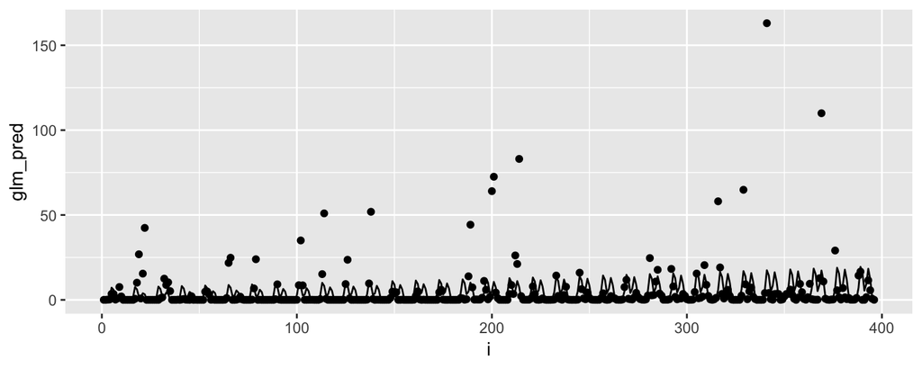

## Hurdle models

In the last example, we used glm() to put the model pieces together ourselves.

Alternatives:

```r
pscl::hurdle()
```

## Hurdle models via mgcv

Given the fits to the hurdle model with GLM() weren’t great, it may be worthwhile to try a GAM

Delta-GAM: We’ll start fitting 2 models to the Conochilus data

```r
lakeWAplanktonRaw = as.data.frame(lakeWAplanktonRaw)
lakeWAplanktonRaw$present =
  ifelse(lakeWAplanktonRaw$Conochilus > 0, 1, 0)

model_01 = gam(present ~ s(Year) +
    s(Month,bs="cc",k=12),
  data=lakeWAplanktonRaw, family = binomial)
model_pos = gam(Conochilus ~ s(Year) +
    s(Month,bs="cc",k=12),
  data=lakeWAplanktonRaw[which(lakeWAplanktonRaw$Conochilus>0),],
  family = Gamma(link="log"))
```

## Hurdle models

Predictions via the GAM. These look maybe slightly better but don’t appear to capture really high observations

```r
lakeWAplanktonRaw$gam_pred = predict(model_01,
  newdata=lakeWAplanktonRaw, type="response") *
  predict(model_pos,
  newdata=lakeWAplanktonRaw, type="response")
```

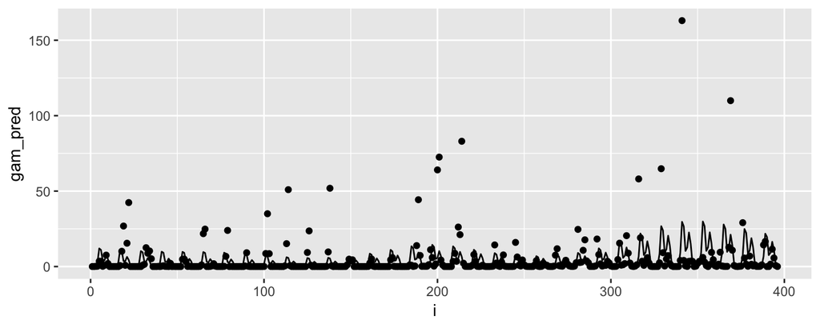

## Extensions with adding mixed effects

Several R packages out there. ‘glmmTMB’ makes ML estimation relatively straightforward if your hurdle model = Poisson or NegBin.

- Instead we’ll add mixed effects with the Tweedie

```r
mod <- glmmTMB(Conochilus~as.factor(Month) + (1|Year),
  family=tweedie(), lakeWAplanktonRaw)
```

## Extensions with adding mixed effects

Comparing these models so far,

| Model | Cor (pred,obs) |
| --- | --- |
| GLM | 0.355 |
| GAM | 0.377 |
| GLMM | 0.339 |

## brms

Bayesian hurdle models, optionally with smooth functions and random effects!

Start with month (factor) and Year (linear trend) in positive model, hurdle is intercept only

```r
library(brms)
mod = brm(bf(Conochilus~ as.factor(Month) + Year,
       hu ~ 1,
      data = lakeWAplanktonRaw, family = hurdle_gamma(),
        chains=1, iter=1000)
```

## brms

Now we can add month covariates to the hurdle part, and a smooth function on Year

- We use *k* to select the wiggliness of the smooth.
- It can be selected automatically, but probably better to put some thought into this!

```r
library(brms)
mod = brm(bf(Conochilus~ as.factor(Month) + s(Year, k=10),
       hu ~ as.factor(Month),
      data = lakeWAplanktonRaw, family = hurdle_gamma(),
        chains=1, iter=1000)
```

## brms

```r
library(brms)
mod = brm(bf(Conochilus~ as.factor(Month) + s(Year, k=10),
       hu ~ as.factor(Month),
      data = lakeWAplanktonRaw, family = hurdle_gamma(),
        chains=1, iter=1000)
```

## brms

Each of these models can be evaluated with LOOIC for model selection, e.g.

```r
library(brms)
mod = brm(bf(Conochilus~ as.factor(Month) + s(Year, k=10),
       hu ~ as.factor(Month),
      data = lakeWAplanktonRaw, family = hurdle_gamma(),
        chains=1, iter=1000)
loo::loo(mod)
```

## Summary: Advantages and disadvantages of Tweedie and delta-GLMMs

Advantages of Tweedie

- Single link function
  - sometimes awkward to have multiple link functions (logit, log) with covariate effects in each
  - one coefficient to interpret / covariate

Advantages of delta-GLMMs

- More flexible
- Estimation can be faster than Tweedie (particularly if power parameter *p* estimated)
- Mechanistic model for 0s that you don’t get with Tweedie